# Resolución Actividad 3 máster Bioinformática UNIR (2025)

Luis Cruz Dévora, Luis Ignacio Figueroa Gomez y Maria Alejandra Ardila Jimenez

2026-06-14

```r
library(tidyverse)
library(gtsummary)
library(factoextra)
library(pheatmap)
library(nortest)
library(broom)
library(gt)
library(scales)
```

# Introducción

En esta actividad se realiza un análisis bioestadístico aplicado a una base de datos de expresión génica de pacientes de la población Los Simpson. El objetivo es explorar los datos, comprobar la presencia de valores faltantes en las variables génicas, evaluar la normalidad, realizar un análisis de componentes principales y aplicar métodos descriptivos e inferenciales.

En este primer apartado se carga la base de datos, se explora su estructura general y se verifica si existen valores faltantes en las variables génicas comprendidas entre ADCY3 y UHMK1.

```r
simpson <- read.csv("Base de datos Los Simpson completa.csv",
                    header = TRUE,
                    sep = ",",
                    stringsAsFactors = FALSE)

dim(simpson)
```

```
## [1] 59 97
```

```r
head(simpson)
```

```
##   X orden                 nombre edad_anios      sexo altura peso_kg imc_kg_m2
## 1 1    10          Barney Gumble         39 Masculino    175     130  42.44898
## 2 2     2          Homer Simpson         40 Masculino    175     120  39.18367
## 3 3    17 Apu Nahasapeemapetilon         35 Masculino    170     110  38.06228
## 4 4     7          Patty Bouvier         40  Femenino    170      95  32.87197
## 5 5     8          Selma Bouvier         40  Femenino    170      93  32.17993
## 6 6     1        Abraham Simpson         80 Masculino    170      90  31.14187
##   ccintura_cm ccadera_cm grasa_corporal_pct longitud_brazos_cm
## 1         110        110                 40                 70
## 2         120        130                 40                 65
## 3          95        100                 25                 65
## 4          75         95                 25                 72
## 5          76         95                 27                 72
## 6          95        105                 30                 65
##   longitud_piernas_cm diametro_biacromial_cm diametro_bicrestal_cm estado_civil
```

[output cut: 111 more lines]

# Carga y limpieza de datos

Primero se revisó la estructura general del dataset para conocer el número de pacientes, el número de variables y los nombres de las columnas disponibles.

```r
nrow(simpson)
```

```
## [1] 59
```

```r
ncol(simpson)
```

```
## [1] 97
```

```r
names(simpson)
```

```
##  [1] "X"                       "orden"
##  [3] "nombre"                  "edad_anios"
##  [5] "sexo"                    "altura"
##  [7] "peso_kg"                 "imc_kg_m2"
##  [9] "ccintura_cm"             "ccadera_cm"
## [11] "grasa_corporal_pct"      "longitud_brazos_cm"
## [13] "longitud_piernas_cm"     "diametro_biacromial_cm"
## [15] "diametro_bicrestal_cm"   "estado_civil"
## [17] "nivel_educativo"         "ocupacion"
## [19] "ingreso_anual_usd"       "lugar_residencia"
## [21] "etnicidad"               "situacion_vivienda"
## [23] "composicion_familiar"    "enfermedades"
## [25] "medicamento"             "frutas_g_d"
## [27] "verduras_g_d"            "cereales_g_d"
## [29] "legumbres_g_d"           "frutos_secos_g_d"
```

[output cut: 34 more lines]

```r
str(simpson)
```

```
## 'data.frame':    59 obs. of  97 variables:
##  $ X                      : int  1 2 3 4 5 6 7 8 9 10 ...
##  $ orden                  : int  10 2 17 7 8 1 18 54 13 32 ...
##  $ nombre                 : chr  "Barney Gumble" "Homer Simpson" "Apu Nahasapeemapetilon" "Patty Bouvier" ...
##  $ edad_anios             : int  39 40 35 40 40 80 45 80 9 50 ...
##  $ sexo                   : chr  "Masculino" "Masculino" "Masculino" "Femenino" ...
##  $ altura                 : int  175 175 170 170 170 170 180 140 130 175 ...
##  $ peso_kg                : int  130 120 110 95 93 90 100 58 50 90 ...
##  $ imc_kg_m2              : num  42.4 39.2 38.1 32.9 32.2 ...
##  $ ccintura_cm            : int  110 120 95 75 76 95 110 70 65 95 ...
##  $ ccadera_cm             : int  110 130 100 95 95 105 115 85 75 100 ...
##  $ grasa_corporal_pct     : int  40 40 25 25 27 30 30 22 20 30 ...
##  $ longitud_brazos_cm     : int  70 65 65 72 72 65 70 45 70 74 ...
##  $ longitud_piernas_cm    : int  90 90 80 80 80 80 85 60 80 88 ...
##  $ diametro_biacromial_cm : int  35 40 37 38 38 38 39 30 30 38 ...
```

[output cut: 83 more lines]

Las variables génicas comienzan en la columna ADCY3 y terminan en la columna UHMK1. Para evitar depender de posiciones fijas, primero se identificaron sus posiciones usando los nombres de las columnas.

```r
inicio <- which(names(simpson) == "ADCY3")
fin <- which(names(simpson) == "UHMK1")

inicio
```

```
## [1] 61
```

```r
fin
```

```
## [1] 97
```

```r
genes <- simpson[, inicio:fin]

dim(genes)
```

```
## [1] 59 37
```

```r
head(genes)
```

```
##        ADCY3       AGRP    ANKRD27       ANO4       BDNF       CADM1      CADM2
## 1  0.8580064  0.8651621 -0.9889536  2.1617928 -0.6955969 -0.56487437 -0.8202175
## 2  2.0395662  0.2525264 -0.7861560  0.6124026 -0.8408645 -1.26160388 -0.7175553
## 3 -0.1893448 -2.3374958  0.8177764 -0.1609404 -0.8889126  0.99505130 -0.6934714
## 4 -0.5400121  0.6622086 -0.1796528 -0.3099262  1.1714303 -0.41047839  1.2391144
## 5 -0.1704537  0.2328619 -0.3531920 -0.5495303  1.2125759 -0.05209537  1.1645903
## 6 -1.0700087  0.2131967 -0.4195207 -1.1204421  1.2158565 -0.22173020  1.2141349
##        CALCR       CNR1     CREBRF       DPP9        FTO       GIPR     GPR151
## 1 -0.2600391  1.3301962  0.7348871  1.3949446 -0.6675089  1.4145876 -1.1935343
## 2 -0.3481127  0.1745937 -1.3501147  0.1350492 -0.2840052 -0.6429128 -0.1664647
## 3  1.0200858 -0.4752763  0.6173916 -0.1600304  0.5992819 -0.6691956  0.4832242
## 4 -0.5670171  0.7572811 -1.5469861 -0.2643656 -0.4901670 -0.5973315  0.3585195
## 5 -0.1627670 -1.9421042  0.7916503 -1.1516758 -0.3155130 -0.1802047 -1.6641660
## 6 -0.6512257  0.6943487 -0.4115895  0.8347046 -1.4478646  1.6477455  0.6666836
##         GPR75     KIAA0586   KIAA1109        KSR2        LEP        LEPR
```

[output cut: 27 more lines]

Después de seleccionar las variables génicas, se evaluó la presencia de valores faltantes. Esto es importante porque los análisis posteriores, como el PCA, requieren trabajar con datos completos.

```r
na_genes <- colSums(is.na(genes))

na_genes
```

```
##    ADCY3     AGRP  ANKRD27     ANO4     BDNF    CADM1    CADM2    CALCR
##        0        0        0        0        0        0        0        0
##     CNR1   CREBRF     DPP9      FTO     GIPR   GPR151    GPR75 KIAA0586
##        0        0        0        0        0        0        0        0
## KIAA1109     KSR2      LEP     LEPR     MC4R    MRAP2     NRP1     NRP2
##        0        0        0        0        0        0        0        0
##    NTRK2    PCSK1    PDE3B     PHIP     POMC    PPARG    ROBO1    SH2B1
##        0        0        0        0        0        0        0        0
##     SIM1    SPARC   TMEM18     UBR2    UHMK1
##        0        0        0        0        0
```

```r
sum(na_genes)
```

```
## [1] 0
```

En caso de existir valores faltantes en las variables génicas, se eliminaron las filas incompletas. Para ello se utilizó `complete.cases()`, que identifica qué pacientes tienen información completa en todos los genes seleccionados.

```r
simpson_limpio <- simpson[complete.cases(genes), ]

nrow(simpson)
```

```
## [1] 59
```

```r
nrow(simpson_limpio)
```

```
## [1] 59
```

## Interpretación

La base de datos fue cargada correctamente y se comprobó que contiene 59 pacientes y 97 variables. Posteriormente, se identificaron las variables de expresión génica, que comienzan en ADCY3 y terminan en UHMK1. En lugar de seleccionar estas columnas únicamente por posición, se localizaron mediante sus nombres para hacer el código más seguro y reproducible.

Una vez seleccionadas las variables génicas, se revisó la presencia de valores faltantes mediante `is.na()` y `colSums()`. Esta revisión es importante porque los análisis posteriores, como el análisis de componentes principales, requieren una matriz de datos completa. Finalmente, se creó un nuevo objeto llamado `simpson_limpio`, que conserva únicamente las filas completas en las variables génicas. De esta forma, el análisis posterior se realizará sobre una base depurada y adecuada para aplicar PCA y otros métodos estadísticos.

# Evaluación de normalidad mediante Shapiro-Wilk

Con el objetivo de evaluar si las variables de expresión génica siguen una distribución normal, se aplicó el test de normalidad de Shapiro-Wilk a cada uno de los genes comprendidos entre ADCY3 y UHMK1.

La hipótesis nula (H0) del test establece que los datos siguen una distribución normal, mientras que la hipótesis alternativa (H1) indica que los datos no siguen una distribución normal.

Para cada gen se obtuvo el correspondiente valor p, que posteriormente se utilizó para evaluar la compatibilidad con la normalidad.

```r
pvalores_shapiro <- sapply(genes, function(x) {
  shapiro.test(x)$p.value
})

tabla_shapiro <- data.frame(
  Gen = names(pvalores_shapiro),
  Pvalor = pvalores_shapiro
)

tabla_shapiro
```

```
##               Gen       Pvalor
## ADCY3       ADCY3 1.104575e-08
## AGRP         AGRP 1.296286e-09
## ANKRD27   ANKRD27 6.469073e-08
## ANO4         ANO4 8.036672e-10
## BDNF         BDNF 2.809579e-11
## CADM1       CADM1 3.139317e-06
## CADM2       CADM2 8.383200e-11
## CALCR       CALCR 8.735421e-07
## CNR1         CNR1 2.493177e-07
## CREBRF     CREBRF 8.447452e-10
## DPP9         DPP9 4.582585e-06
## FTO           FTO 7.547348e-06
## GIPR         GIPR 2.502880e-07
## GPR151     GPR151 1.980377e-04
## GPR75       GPR75 8.686794e-08
## KIAA0586 KIAA0586 4.647230e-06
## KIAA1109 KIAA1109 7.747962e-05
## KSR2         KSR2 1.051617e-06
## LEP           LEP 2.105453e-09
## LEPR         LEPR 8.933047e-08
## MC4R         MC4R 4.507145e-05
## MRAP2       MRAP2 1.040271e-11
## NRP1         NRP1 2.585638e-06
## NRP2         NRP2 7.185121e-08
## NTRK2       NTRK2 1.006829e-08
## PCSK1       PCSK1 2.316967e-06
## PDE3B       PDE3B 1.351462e-09
## PHIP         PHIP 1.203390e-07
## POMC         POMC 3.622517e-08
## PPARG       PPARG 3.400075e-08
## ROBO1       ROBO1 1.686373e-09
## SH2B1       SH2B1 3.648850e-06
## SIM1         SIM1 8.908516e-09
## SPARC       SPARC 2.670831e-05
## TMEM18     TMEM18 1.147261e-06
## UBR2         UBR2 1.509604e-08
## UHMK1       UHMK1 2.670551e-07
```

## Interpretación del test de normalidad

Se aplicó el test de Shapiro-Wilk a las 37 variables de expresión génica comprendidas entre ADCY3 y UHMK1.

Los resultados mostraron que todos los genes presentaron valores p inferiores a 0.05. En consecuencia, se rechazó la hipótesis nula de normalidad para todas las variables analizadas.

Por tanto, ninguna de las variables génicas presentó una distribución compatible con la normalidad según el criterio α = 0.05. Este resultado indica que los datos presentan distribuciones alejadas de la normal y debe tenerse en cuenta en análisis estadísticos posteriores.

No obstante, el Análisis de Componentes Principales (PCA) puede aplicarse igualmente, ya que esta técnica no exige estrictamente que todas las variables sigan una distribución normal.

# Análisis de Componentes Principales

```r
genes_escalados <- scale(genes)

pca <- prcomp(genes_escalados)

summary(pca)
```

```
## Importance of components:
##                           PC1     PC2     PC3     PC4     PC5     PC6     PC7
## Standard deviation     2.1490 1.77984 1.55393 1.50621 1.40770 1.34487 1.32111
## Proportion of Variance 0.1248 0.08562 0.06526 0.06132 0.05356 0.04888 0.04717
## Cumulative Proportion  0.1248 0.21043 0.27570 0.33701 0.39057 0.43945 0.48662
##                            PC8     PC9    PC10    PC11    PC12    PC13    PC14
## Standard deviation     1.22276 1.21125 1.16838 1.11580 1.09518 1.04437 1.03150
## Proportion of Variance 0.04041 0.03965 0.03689 0.03365 0.03242 0.02948 0.02876
## Cumulative Proportion  0.52703 0.56668 0.60358 0.63723 0.66964 0.69912 0.72788
##                           PC15    PC16    PC17    PC18    PC19    PC20    PC21
## Standard deviation     0.96209 0.94739 0.93230 0.90059 0.86173 0.82852 0.80968
## Proportion of Variance 0.02502 0.02426 0.02349 0.02192 0.02007 0.01855 0.01772
## Cumulative Proportion  0.75290 0.77715 0.80065 0.82257 0.84264 0.86119 0.87891
##                          PC22    PC23    PC24   PC25    PC26    PC27    PC28
## Standard deviation     0.7671 0.72833 0.69434 0.6550 0.62202 0.57551 0.55218
## Proportion of Variance 0.0159 0.01434 0.01303 0.0116 0.01046 0.00895 0.00824
## Cumulative Proportion  0.8948 0.90915 0.92218 0.9338 0.94423 0.95318 0.96142
##                           PC29   PC30    PC31    PC32    PC33    PC34    PC35
## Standard deviation     0.52291 0.4903 0.47692 0.43690 0.38412 0.34495 0.30347
## Proportion of Variance 0.00739 0.0065 0.00615 0.00516 0.00399 0.00322 0.00249
## Cumulative Proportion  0.96881 0.9753 0.98146 0.98662 0.99061 0.99382 0.99631
##                           PC36    PC37
## Standard deviation     0.28857 0.23071
## Proportion of Variance 0.00225 0.00144
## Cumulative Proportion  0.99856 1.00000
```

```r
scores <- pca$x[, 1:6]

simpson_limpio <- cbind(simpson_limpio, scores)

tail(names(simpson_limpio))
```

```
## [1] "PC1" "PC2" "PC3" "PC4" "PC5" "PC6"
```

## Visualización de la varianza explicada

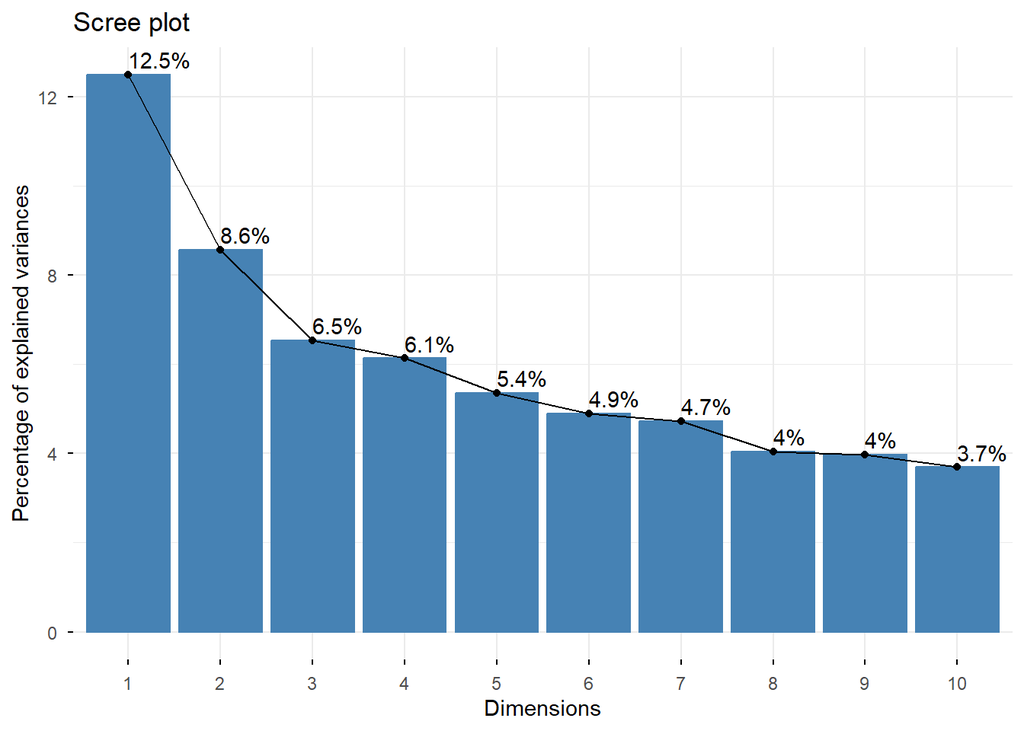

```r
fviz_eig(pca, addlabels = TRUE)
```

## Scree plot e interpretación de la varianza explicada

El scree plot muestra la proporción de variabilidad explicada por cada componente principal.

La primera componente principal (PC1) explicó aproximadamente el 12.5% de la variabilidad total, mientras que la segunda componente principal (PC2) explicó el 8.6%. A partir de la tercera componente se observa una disminución progresiva de la varianza explicada.

No se aprecia un punto de corte abrupto, lo que indica que la variabilidad de los datos se encuentra distribuida entre múltiples componentes. Este comportamiento es habitual en estudios de expresión génica donde numerosas variables contribuyen simultáneamente a la estructura de los datos.

## Gráfico de individuos del PCA

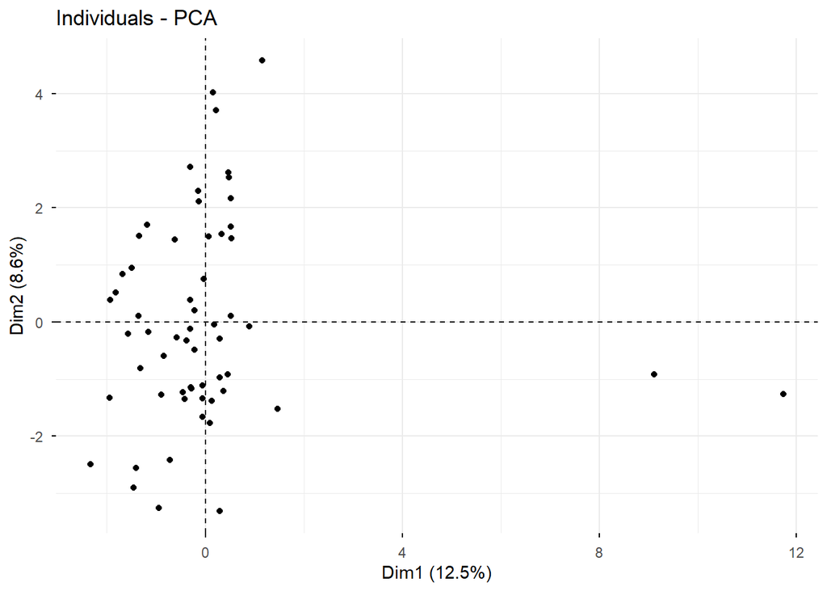

```r
fviz_pca_ind(
  pca,
  geom = "point",
  repel = TRUE
)
```

## Interpretacion del gráfico de individuos del PCA

El gráfico de individuos permite visualizar la distribución de los pacientes en el espacio definido por las dos primeras componentes principales. En este caso, se observa que la mayoría de los individuos se agrupan en una zona central, mientras que algunos pacientes, especialmente los individuos 1 y 2, aparecen más separados del grupo principal.

Esta separación sugiere que dichos individuos podrían presentar un perfil de expresión génica diferente al resto de la muestra. Sin embargo, esta observación debe interpretarse con cautela, ya que el gráfico solo representa las dos primeras componentes principales y estas explican una parte limitada de la variabilidad total.

## Gráfico de variables coloreado por cos2

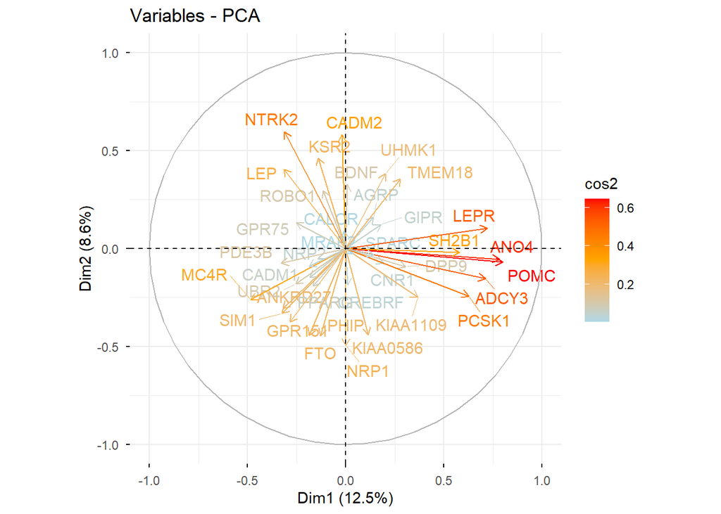

```r
fviz_pca_var(
  pca,
  col.var = "cos2",
  gradient.cols = c("lightblue", "orange", "red"),
  repel = TRUE
)
```

## Interpretacion del gráfico de variables coloreado según cos2

El gráfico de variables muestra la representación de los genes en el espacio de las dos primeras componentes principales. El color indica la calidad de representación de cada gen mediante el valor de cos2. Los genes con colores más intensos están mejor representados por las componentes principales PC1 y PC2.

Se observa que algunos genes, como LEPR, SH2B1, ADCY3, PCSK1 y NTRK2, presentan una mayor contribución visual en el plano factorial, por lo que podrían estar relacionados con la variabilidad principal observada en la expresión génica de los pacientes.

## Contribución de genes a PC1

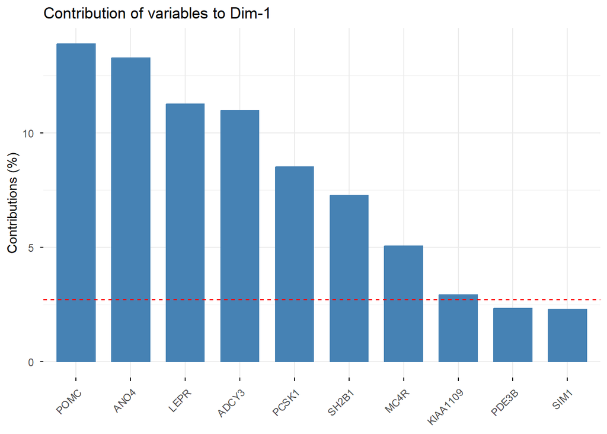

```r
fviz_contrib(
  pca,
  choice = "var",
  axes = 1,
  top = 10
)
```

## Interpretacion de la contribución de las variables a la PC1

La contribución de las variables a la primera componente principal permite identificar los genes que más influyen en la construcción de esta componente. Los genes con mayor porcentaje de contribución son los que explican en mayor medida la variabilidad capturada por PC1.

Este análisis es útil para priorizar genes relevantes dentro del PCA, especialmente porque en estudios de expresión génica no todos los genes aportan de la misma manera a la estructura global de los datos.

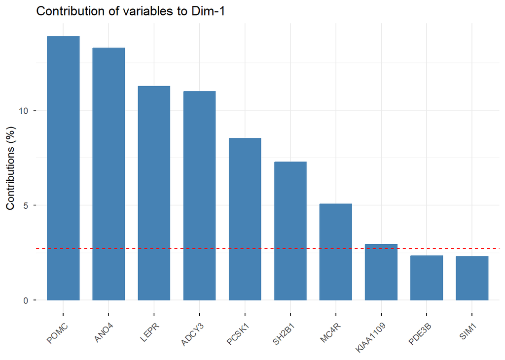

```r
fviz_contrib(
  pca,
  choice = "var",
  axes = 1,
  top = 10
)
```

Los genes con mayor contribución en PC2 pueden estar asociados a patrones de expresión distintos a los observados en PC1, lo que refuerza la utilidad del PCA para resumir información compleja en pocas dimensiones.

## Clasificación de pacientes según IMC

```r
simpson_limpio$categoria_imc <- cut(
  simpson_limpio$imc_kg_m2,
  breaks = c(-Inf, 24.9, 29.9, Inf),
  labels = c("Normal", "Sobrepeso", "Obesidad")
)

table(simpson_limpio$categoria_imc)
```

```
##
##    Normal Sobrepeso  Obesidad
##        32        20         7
```

Se creó una variable categórica de IMC para clasificar a los pacientes en Normal, Sobrepeso u Obesidad.

## Interpretacion de la clasificación de los pacientes según IMC

A partir de la variable imc_kg_m2 se creó una nueva variable categórica de IMC. Los pacientes fueron clasificados como Normal, Sobrepeso u Obesidad según los puntos de corte habituales del índice de masa corporal.

Esta variable será utilizada para visualizar si existe una separación de los pacientes en el PCA según su estado ponderal.

## Corrección del PCA usando la base limpia

```r
genes_limpios <- simpson_limpio[, inicio:fin]

genes_escalados <- scale(genes_limpios)

pca <- prcomp(genes_escalados)

scores <- as.data.frame(pca$x[, 1:6])

simpson_limpio <- cbind(
  simpson_limpio[, !(names(simpson_limpio) %in% names(scores))],
  scores
)
```

El PCA se recalculó utilizando únicamente los pacientes completos para las variables génicas. Esto asegura que el número de individuos del objeto PCA coincida con el número de filas del dataframe limpio.

## PCA coloreado por categoría de IMC

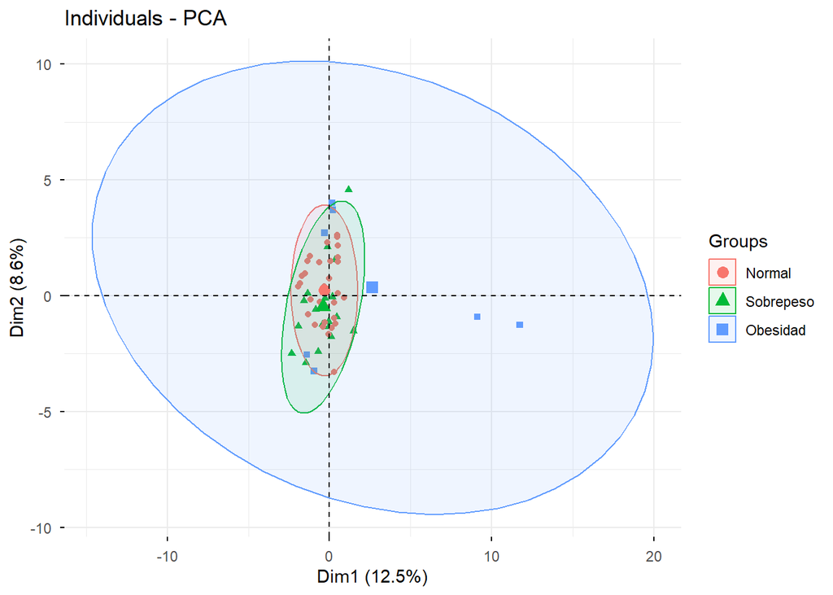

```r
fviz_pca_ind(
  pca,
  geom = "point",
  habillage = simpson_limpio$categoria_imc,
  addEllipses = TRUE,
  repel = TRUE
)
```

El gráfico permite explorar si los pacientes se agrupan según su categoría de IMC en el espacio definido por las dos primeras componentes principales.

## Clustering de variables génicas

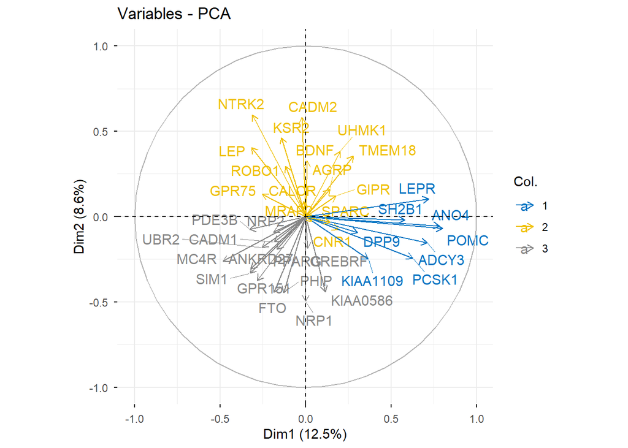

```r
coord_var <- get_pca_var(pca)$coord

set.seed(123)

cluster_var <- kmeans(coord_var[, 1:2], centers = 3)

fviz_pca_var(
  pca,
  col.var = as.factor(cluster_var$cluster),
  palette = "jco",
  repel = TRUE
)
```

Se realizó un agrupamiento de las variables génicas utilizando sus coordenadas en las dos primeras componentes principales. Para ello se aplicó k-means con tres clusters.

Este análisis permite identificar grupos de genes con patrones similares dentro del espacio del PCA.

## Clustering de individuos basado en los scores del PCA

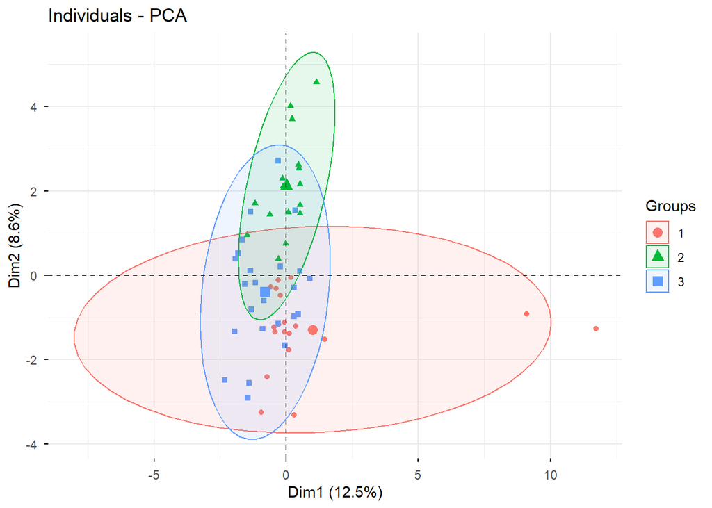

```r
scores_pca <- as.data.frame(pca$x[, 1:6])

set.seed(123)

cluster_ind <- kmeans(scores_pca, centers = 3)

simpson_limpio$cluster_pca <- as.factor(cluster_ind$cluster)

fviz_pca_ind(
  pca,
  geom = "point",
  habillage = simpson_limpio$cluster_pca,
  addEllipses = TRUE,
  repel = TRUE
)
```

Se realizó un agrupamiento de los pacientes utilizando los scores de las primeras seis componentes principales. Para ello se aplicó k-means con tres clusters, con el objetivo de identificar posibles subgrupos de pacientes según sus perfiles globales de expresión génica.

La visualización muestra la distribución de los clusters en el espacio definido por PC1 y PC2. Si los grupos aparecen separados, esto sugiere perfiles de expresión génica diferenciados entre pacientes. Si existe solapamiento, indica que la separación entre subgrupos no es completa en las dos primeras componentes.

## Heatmap de correlaciones de Spearman entre genes y componentes principales

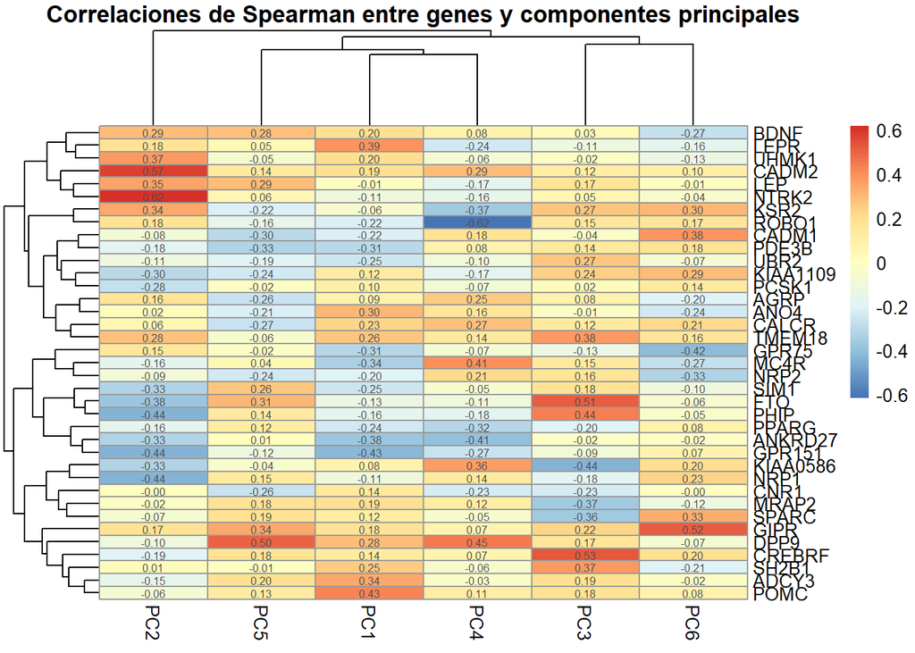

```r
library(pheatmap)

cor_genes_pc <- cor(
  genes_limpios,
  simpson_limpio[, c("PC1", "PC2", "PC3", "PC4", "PC5", "PC6")],
  method = "spearman"
)

pheatmap(
  cor_genes_pc,
  cluster_rows = TRUE,
  cluster_cols = TRUE,
  display_numbers = TRUE,
  fontsize_number = 6,
  main = "Correlaciones de Spearman entre genes y componentes principales"
)
```

Se construyó un heatmap con las correlaciones de Spearman entre las variables génicas y las primeras seis componentes principales. Se utilizó la correlación de Spearman debido a que los genes no siguieron una distribución normal según el test de Shapiro-Wilk.

Este análisis permite identificar qué genes se relacionan con cada componente principal. Las correlaciones positivas indican que mayores valores de expresión génica se asocian con mayores scores de la componente, mientras que las correlaciones negativas indican una relación inversa.

## Creación de terciles para las componentes principales

```r
simpson_limpio$PC1_t <- cut(
  simpson_limpio$PC1,
  breaks = quantile(simpson_limpio$PC1,
                    probs = c(0, 1/3, 2/3, 1),
                    na.rm = TRUE),
  include.lowest = TRUE,
  labels = c("T1", "T2", "T3")
)

simpson_limpio$PC2_t <- cut(
  simpson_limpio$PC2,
  breaks = quantile(simpson_limpio$PC2,
                    probs = c(0, 1/3, 2/3, 1),
                    na.rm = TRUE),
  include.lowest = TRUE,
  labels = c("T1", "T2", "T3")
)

simpson_limpio$PC3_t <- cut(
  simpson_limpio$PC3,
  breaks = quantile(simpson_limpio$PC3,
                    probs = c(0, 1/3, 2/3, 1),
                    na.rm = TRUE),
  include.lowest = TRUE,
  labels = c("T1", "T2", "T3")
)

table(simpson_limpio$PC1_t)
```

```
##
## T1 T2 T3
## 20 19 20
```

```r
table(simpson_limpio$PC2_t)
```

```
##
## T1 T2 T3
## 20 19 20
```

```r
table(simpson_limpio$PC3_t)
```

```
##
## T1 T2 T3
## 20 19 20
```

Las tres primeras componentes principales se dividieron en terciles utilizando los percentiles 33.3% y 66.7%. De esta manera, cada paciente fue clasificado en un grupo de valores bajos (T1), intermedios (T2) o altos (T3) para cada componente principal.

## Tabla descriptiva según terciles de PC1

```r
library(gtsummary)

tabla_PC1 <- simpson_limpio |>
  dplyr::select(PC1_t, all_of(colnames(genes_limpios))) |>
  tbl_summary(
    by = PC1_t,
    type = everything() ~ "continuous",
    statistic = everything() ~ "{median} ({p25}-{p75})",
    digits = everything() ~ 1
  ) |>
  add_p(
    test = everything() ~ "kruskal.test",
    pvalue_fun = ~style_pvalue(.x, digits = 3)
  )

tabla_PC1
```

| **Characteristic** | **T1** N = 20<sup>1</sup> | **T2** N = 19<sup>1</sup> | **T3** N = 20<sup>1</sup> | **p-value**<sup>2</sup> |
| --- | --- | --- | --- | --- |
| ADCY3 | -0.8 (-0.9--0.5) | -0.5 (-0.8--0.2) | -0.2 (-0.8--0.2) | 0.016 |
| AGRP | 0.2 (-0.2-0.5) | 0.2 (-0.2-0.3) | 0.2 (-0.2-0.7) | 0.707 |
| ANKRD27 | 0.8 (-0.2-0.8) | -0.2 (-0.4-2.1) | -0.4 (-0.4--0.2) | 0.046 |
| ANO4 | -0.5 (-0.8--0.3) | -0.5 (-0.5--0.3) | -0.3 (-0.5--0.2) | 0.208 |
| BDNF | -0.8 (-0.9--0.7) | -0.8 (-0.9--0.7) | -0.7 (-0.8-1.2) | 0.208 |
| CADM1 | -0.4 (-0.6-1.0) | -0.1 (-0.6-1.0) | -0.6 (-0.9--0.4) | 0.029 |
| CADM2 | -0.7 (-0.7--0.6) | -0.7 (-0.7-1.2) | -0.6 (-0.7-1.2) | 0.367 |
| CALCR | -0.3 (-1.0-1.0) | -0.3 (-0.7-1.0) | -0.2 (-0.3-1.5) | 0.308 |
| CNR1 | -0.2 (-0.3-0.7) | -0.2 (-1.9-0.7) | -0.2 (-0.3-0.7) | 0.667 |
| CREBRF | 0.4 (-1.4-0.7) | 0.6 (-1.4-0.7) | 0.7 (-1.4-0.8) | 0.322 |
| DPP9 | -1.2 (-1.5--0.2) | 0.7 (-0.3-0.8) | -0.1 (-0.7-0.8) | 0.025 |
| FTO | 0.6 (0.2-0.9) | 0.6 (-0.3-0.9) | 0.6 (-0.4-0.9) | 0.756 |
| GIPR | -0.4 (-0.8-0.0) | 0.0 (-0.2-1.6) | -0.2 (-0.6-0.7) | 0.042 |
| GPR151 | 0.4 (0.0-0.7) | 0.5 (-0.2-0.7) | -0.2 (-1.2-0.2) | 0.008 |
| GPR75 | 0.6 (0.3-0.7) | 0.3 (-1.1-0.7) | 0.1 (-1.5-0.5) | 0.090 |
| KIAA0586 | 0.5 (-0.5-0.8) | 0.7 (-0.5-0.9) | 0.7 (-0.5-0.9) | 0.822 |
| KIAA1109 | -0.5 (-0.7-0.4) | -0.5 (-0.7-0.3) | -0.5 (-0.7-0.4) | 0.830 |
| KSR2 | -0.2 (-0.6-0.2) | 0.0 (-0.4-0.6) | -0.2 (-0.8-0.2) | 0.570 |
| LEP | 1.0 (-0.5-1.1) | 1.0 (-0.7-1.1) | 1.0 (0.4-1.1) | 0.393 |
| LEPR | -0.9 (-0.9--0.2) | -0.2 (-0.9-0.0) | -0.2 (-0.7-0.0) | 0.057 |
| MC4R | 0.5 (0.0-1.2) | 0.1 (0.0-0.9) | -0.5 (-0.5-0.5) | 0.039 |
| MRAP2 | -0.2 (-0.5--0.2) | -0.2 (-0.5--0.2) | -0.2 (-0.3--0.1) | 0.246 |
| NRP1 | 0.7 (0.0-0.8) | 0.0 (0.0-0.7) | 0.0 (-1.6-1.0) | 0.674 |
| NRP2 | 0.9 (-1.2-0.9) | -0.6 (-1.7-0.9) | -0.9 (-1.2-0.5) | 0.326 |
| NTRK2 | 1.1 (-0.4-1.1) | -0.4 (-0.6-1.3) | 1.1 (-0.6-1.1) | 0.943 |
| PCSK1 | -0.5 (-1.2--0.1) | -0.5 (-1.2-0.0) | -0.5 (-0.7--0.3) | 0.871 |
| PDE3B | 0.9 (0.3-0.9) | 0.3 (0.2-0.9) | 0.2 (-0.6-0.9) | 0.089 |
| PHIP | 0.1 (-0.9-1.1) | 0.1 (-0.9-0.1) | 0.1 (-0.2-0.1) | 0.518 |
| POMC | -0.6 (-0.7--0.3) | -0.3 (-0.6--0.2) | -0.2 (-0.6-0.1) | 0.010 |
| PPARG | -0.4 (-0.8-1.2) | -0.4 (-1.0-0.1) | -1.0 (-1.1--0.4) | 0.064 |
| ROBO1 | 0.6 (-0.5-0.7) | 0.6 (0.2-0.8) | 0.2 (-1.3-0.6) | 0.158 |
| SH2B1 | -0.3 (-1.1--0.1) | -0.2 (-0.9--0.1) | -0.2 (-0.9-0.0) | 0.317 |
| SIM1 | 1.2 (0.4-1.2) | 1.0 (-0.2-1.2) | 0.4 (-0.6-1.2) | 0.144 |
| SPARC | -0.1 (-0.3-0.0) | 0.0 (-1.2-1.1) | 0.0 (-0.7-0.9) | 0.687 |
| TMEM18 | -0.3 (-1.3-0.2) | 0.7 (-0.3-1.0) | 0.6 (-0.4-0.8) | 0.030 |
| UBR2 | 0.7 (-0.7-1.3) | 0.7 (-0.7-1.5) | -0.7 (-0.7-0.7) | 0.116 |
| UHMK1 | -0.6 (-0.7-0.7) | -0.7 (-2.0--0.6) | 0.7 (-0.6-0.7) | 0.022 |

<sup>1</sup> Median (Q1-Q3)  
<sup>2</sup> Kruskal-Wallis rank sum test

La tabla muestra la distribución de los genes según los terciles de la primera componente principal. Debido a que todas las variables génicas rechazaron normalidad, se emplearon la mediana y el rango intercuartílico como medidas descriptivas, junto con la prueba de Kruskal-Wallis para la comparación entre grupos.

## Tabla descriptiva según terciles de PC2

```r
tabla_PC2 <- simpson_limpio |>
  dplyr::select(PC2_t, all_of(colnames(genes_limpios))) |>
  tbl_summary(
    by = PC2_t,
    type = everything() ~ "continuous",
    statistic = everything() ~ "{median} ({p25}-{p75})",
    digits = everything() ~ 1
  ) |>
  add_p(
    test = everything() ~ "kruskal.test",
    pvalue_fun = ~style_pvalue(.x, digits = 3)
  )

tabla_PC2
```

| **Characteristic** | **T1** N = 20<sup>1</sup> | **T2** N = 19<sup>1</sup> | **T3** N = 20<sup>1</sup> | **p-value**<sup>2</sup> |
| --- | --- | --- | --- | --- |
| ADCY3 | -0.2 (-0.8--0.2) | -0.5 (-0.8--0.2) | -0.5 (-0.8--0.2) | 0.490 |
| AGRP | 0.2 (-0.2-0.3) | 0.2 (0.2-0.3) | 0.2 (0.0-0.7) | 0.550 |
| ANKRD27 | 0.3 (-0.2-2.1) | 0.8 (-0.4-0.8) | -0.4 (-0.4--0.2) | 0.040 |
| ANO4 | -0.5 (-0.5--0.3) | -0.3 (-0.5--0.1) | -0.5 (-0.5--0.3) | 0.117 |
| BDNF | -0.8 (-0.9--0.7) | -0.7 (-0.9--0.7) | -0.7 (-0.8-1.2) | 0.154 |
| CADM1 | -0.2 (-0.6-1.0) | -0.4 (-0.6-1.0) | -0.4 (-0.6--0.3) | 0.512 |
| CADM2 | -0.7 (-0.8--0.7) | -0.7 (-0.7-1.2) | 1.2 (-0.6-1.2) | <0.001 |
| CALCR | -0.3 (-0.8-1.5) | -0.3 (-0.7-1.0) | 0.4 (-0.6-1.5) | 0.337 |
| CNR1 | -0.2 (-0.3-0.7) | -0.2 (-0.3-0.7) | -0.2 (-1.1-0.7) | 0.996 |
| CREBRF | 0.7 (0.4-0.8) | 0.6 (-1.4-0.7) | 0.1 (-1.4-0.8) | 0.316 |
| DPP9 | 0.3 (-0.7-0.8) | -0.3 (-1.2-0.7) | -0.3 (-1.2-0.8) | 0.302 |
| FTO | 0.9 (0.6-1.7) | 0.6 (-0.3-0.9) | -0.3 (-1.4-0.9) | 0.025 |
| GIPR | -0.2 (-0.6-1.5) | -0.2 (-1.0-0.0) | -0.2 (-0.2-0.0) | 0.402 |
| GPR151 | 0.6 (0.3-1.0) | -0.2 (-1.2-0.5) | -0.2 (-0.7-0.4) | 0.002 |
| GPR75 | 0.3 (-1.5-0.6) | 0.4 (-1.1-0.7) | 0.4 (-0.5-0.7) | 0.513 |
| KIAA0586 | 0.8 (0.5-0.9) | 0.7 (0.5-0.9) | -0.5 (-1.4-0.8) | 0.053 |
| KIAA1109 | -0.1 (-0.5-0.4) | -0.5 (-0.7-0.3) | -0.6 (-1.6--0.1) | 0.028 |
| KSR2 | -0.4 (-0.8-0.1) | -0.2 (-0.4-0.0) | 0.2 (-0.4-2.0) | 0.041 |
| LEP | -0.3 (-0.7-1.1) | 1.0 (-0.7-1.1) | 1.0 (1.0-1.1) | 0.022 |
| LEPR | -0.8 (-0.9--0.2) | -0.2 (-0.9-0.0) | -0.2 (-0.9-0.0) | 0.399 |
| MC4R | 0.9 (-0.2-1.1) | 0.1 (0.0-1.2) | 0.1 (-0.2-0.9) | 0.771 |
| MRAP2 | -0.2 (-0.5--0.2) | -0.2 (-0.5--0.2) | -0.3 (-0.5--0.2) | 0.884 |
| NRP1 | 0.7 (0.0-1.3) | 0.7 (0.0-0.8) | -1.2 (-1.6-0.4) | 0.009 |
| NRP2 | -0.6 (-1.4-0.9) | -0.6 (-1.2-0.9) | -0.1 (-1.4-0.9) | 0.914 |
| NTRK2 | -0.4 (-0.6--0.4) | 1.1 (-0.6-1.1) | 1.1 (1.1-1.3) | <0.001 |
| PCSK1 | -0.3 (-0.6-0.0) | -0.5 (-1.2--0.3) | -0.6 (-1.2--0.5) | 0.050 |
| PDE3B | 0.9 (0.2-0.9) | 0.9 (0.2-0.9) | 0.3 (0.2-0.9) | 0.448 |
| PHIP | 0.1 (0.1-1.1) | 0.1 (-0.9-0.1) | -0.2 (-0.9-0.1) | 0.019 |
| POMC | -0.3 (-0.6--0.2) | -0.3 (-0.7-0.1) | -0.3 (-0.6--0.2) | 0.864 |
| PPARG | -0.4 (-1.0-0.3) | -0.4 (-1.0-0.1) | -0.7 (-1.1--0.2) | 0.258 |
| ROBO1 | 0.4 (-1.3-0.7) | -0.5 (-2.2-0.8) | 0.6 (0.2-0.6) | 0.401 |
| SH2B1 | -0.2 (-0.9--0.1) | -0.2 (-0.9--0.1) | -0.2 (-0.9-0.0) | 0.917 |
| SIM1 | 1.2 (0.4-1.2) | 1.0 (-0.2-1.2) | 0.4 (-0.7-1.2) | 0.155 |
| SPARC | 0.0 (-0.3-1.1) | 0.0 (-0.2-0.8) | -0.3 (-1.2-0.8) | 0.195 |
| TMEM18 | -0.3 (-0.7-0.9) | -0.2 (-0.7-0.8) | 0.7 (-0.3-0.8) | 0.179 |
| UBR2 | 0.7 (-0.7-1.3) | 0.7 (-0.7-1.3) | -0.7 (-0.7-1.3) | 0.664 |
| UHMK1 | -0.7 (-2.0-0.0) | -0.6 (-0.7-0.7) | 0.7 (-0.6-0.7) | 0.032 |

<sup>1</sup> Median (Q1-Q3)  
<sup>2</sup> Kruskal-Wallis rank sum test

La comparación por terciles de la segunda componente principal permite identificar genes cuya expresión podría estar asociada a la variabilidad resumida por PC2.

## Tabla descriptiva según terciles de PC3

```r
tabla_PC3 <- simpson_limpio |>
  dplyr::select(PC3_t, all_of(colnames(genes_limpios))) |>
  tbl_summary(
    by = PC3_t,
    type = everything() ~ "continuous",
    statistic = everything() ~ "{median} ({p25}-{p75})",
    digits = everything() ~ 1
  ) |>
  add_p(
    test = everything() ~ "kruskal.test",
    pvalue_fun = ~style_pvalue(.x, digits = 3)
  )

tabla_PC3
```

| **Characteristic** | **T1** N = 20<sup>1</sup> | **T2** N = 19<sup>1</sup> | **T3** N = 20<sup>1</sup> | **p-value**<sup>2</sup> |
| --- | --- | --- | --- | --- |
| ADCY3 | -0.5 (-0.9--0.4) | -0.5 (-0.8--0.2) | -0.4 (-0.8--0.2) | 0.351 |
| AGRP | 0.2 (-0.2-0.6) | 0.3 (0.2-0.7) | 0.2 (-0.2-0.5) | 0.657 |
| ANKRD27 | -0.2 (-0.4-1.5) | -0.2 (-0.4-0.8) | -0.2 (-0.4-2.1) | 0.719 |
| ANO4 | -0.5 (-0.5--0.3) | -0.3 (-0.5--0.2) | -0.5 (-0.5--0.2) | 0.861 |
| BDNF | -0.8 (-0.9-0.3) | -0.7 (-0.8-1.2) | -0.8 (-0.9--0.7) | 0.587 |
| CADM1 | -0.5 (-0.9-1.0) | -0.4 (-0.6-1.0) | -0.4 (-0.6--0.1) | 0.507 |
| CADM2 | -0.6 (-0.7--0.6) | -0.7 (-0.7-1.2) | -0.6 (-0.7-1.2) | 0.399 |
| CALCR | -0.3 (-0.8-1.0) | -0.3 (-0.6-2.0) | -0.3 (-0.7-1.0) | 0.441 |
| CNR1 | 0.7 (-0.3-0.7) | -0.2 (-0.3-0.7) | -0.3 (-1.9-0.7) | 0.151 |
| CREBRF | -1.4 (-1.4-0.7) | 0.6 (-1.4-0.7) | 0.7 (0.6-0.8) | 0.001 |
| DPP9 | -0.3 (-1.5-0.8) | -0.3 (-1.2-0.7) | 0.7 (-0.7-0.8) | 0.369 |
| FTO | 0.6 (-0.3-0.6) | 0.6 (-1.4-0.9) | 0.9 (0.8-1.7) | <0.001 |
| GIPR | -0.2 (-0.6-0.0) | -0.2 (-0.6-0.0) | 0.0 (-0.4-1.6) | 0.128 |
| GPR151 | 0.3 (-0.2-0.7) | 0.1 (-1.2-0.5) | 0.2 (-0.2-0.6) | 0.481 |
| GPR75 | 0.5 (-0.5-0.6) | 0.4 (-1.1-0.7) | 0.2 (-1.1-0.6) | 0.498 |
| KIAA0586 | 0.9 (0.6-0.9) | 0.5 (-0.5-0.9) | 0.3 (-0.5-0.7) | 0.019 |
| KIAA1109 | -0.5 (-1.1--0.5) | -0.5 (-0.7-0.4) | -0.1 (-0.7-0.4) | 0.250 |
| KSR2 | -0.3 (-0.8--0.2) | 0.0 (-0.2-0.6) | 0.0 (-0.4-0.6) | 0.027 |
| LEP | 1.0 (-0.7-1.1) | 1.0 (-0.3-1.1) | 1.0 (-0.5-1.1) | 0.525 |
| LEPR | -0.2 (-0.9-0.0) | -0.7 (-0.9-0.0) | -0.4 (-0.9--0.2) | 0.778 |
| MC4R | 0.0 (-0.5-0.9) | 0.1 (0.0-1.2) | 0.5 (0.0-1.1) | 0.443 |
| MRAP2 | -0.2 (-0.4-2.4) | -0.2 (-0.5--0.2) | -0.3 (-0.5--0.2) | 0.070 |
| NRP1 | 0.3 (0.0-0.8) | 0.2 (-1.6-1.3) | 0.0 (-1.4-0.7) | 0.454 |
| NRP2 | -0.9 (-1.4-0.9) | -0.6 (-1.2-0.9) | 0.8 (-1.2-0.9) | 0.399 |
| NTRK2 | 1.1 (-0.5-1.1) | 1.1 (-0.4-1.1) | -0.4 (-0.6-1.3) | 0.907 |
| PCSK1 | -0.5 (-1.0--0.3) | -0.5 (-0.7--0.2) | -0.5 (-1.2-0.0) | 0.956 |
| PDE3B | 0.6 (-0.5-0.9) | 0.9 (0.2-0.9) | 0.3 (0.2-0.9) | 0.900 |
| PHIP | 0.1 (-0.9-0.1) | 0.1 (-0.9-0.1) | 0.1 (0.1-2.0) | 0.002 |
| POMC | -0.6 (-0.7--0.2) | -0.3 (-0.7-0.1) | -0.3 (-0.6--0.1) | 0.283 |
| PPARG | -0.4 (-1.0-0.4) | -0.4 (-1.0-0.1) | -0.4 (-1.0--0.2) | 0.510 |
| ROBO1 | 0.4 (-1.3-0.8) | 0.2 (-0.5-0.6) | 0.6 (0.2-0.8) | 0.527 |
| SH2B1 | -1.1 (-1.3--0.2) | -0.1 (-0.2-0.1) | -0.2 (-0.9--0.1) | <0.001 |
| SIM1 | -0.2 (-0.2-1.2) | 1.0 (-0.9-1.2) | 1.2 (1.0-1.2) | 0.310 |
| SPARC | 0.0 (-0.1-0.9) | 0.0 (-0.2-0.8) | -0.3 (-1.2-0.4) | 0.050 |
| TMEM18 | -0.7 (-0.7-0.7) | 0.6 (-0.7-0.7) | 0.8 (-0.3-1.0) | 0.014 |
| UBR2 | -0.7 (-0.7-0.7) | 0.7 (-0.7-1.3) | 0.7 (-0.7-1.5) | 0.190 |
| UHMK1 | -0.6 (-1.4-0.7) | 0.7 (-0.7-0.7) | -0.7 (-1.4-0.7) | 0.309 |

<sup>1</sup> Median (Q1-Q3)  
<sup>2</sup> Kruskal-Wallis rank sum test

La tabla descriptiva según los terciles de la tercera componente principal resume las diferencias observadas en la expresión génica entre los tres grupos de pacientes definidos por PC3.

## Creación de la variable sobrepeso

```r
simpson_limpio$sobrepeso <- ifelse(
  simpson_limpio$imc_kg_m2 >= 25,
  1,
  0
)

table(simpson_limpio$sobrepeso)
```

```
##
##  0  1
## 32 27
```

Se creó una variable binaria de sobrepeso a partir del índice de masa corporal. Los individuos con IMC igual o superior a 25 kg/m² fueron clasificados como sobrepeso (1), mientras que los restantes fueron clasificados como no sobrepeso (0).

## Modelo de regresión logística sin ajuste

```r
modelo1 <- glm(
  sobrepeso ~ PC1_t + PC2_t + PC3_t,
  data = simpson_limpio,
  family = binomial()
)

summary(modelo1)
```

```
##
## Call:
## glm(formula = sobrepeso ~ PC1_t + PC2_t + PC3_t, family = binomial(),
##     data = simpson_limpio)
##
## Coefficients:
##             Estimate Std. Error z value Pr(>|z|)
## (Intercept)  0.07987    0.72474   0.110   0.9122
## PC1_tT2      0.17696    0.69787   0.254   0.7998
## PC1_tT3      0.27195    0.68846   0.395   0.6928
## PC2_tT2     -0.65885    0.69857  -0.943   0.3456
## PC2_tT3     -1.43347    0.71335  -2.009   0.0445 *
## PC3_tT2      0.89625    0.68806   1.303   0.1927
## PC3_tT3     -0.03059    0.70631  -0.043   0.9655
## ---
## Signif. codes:  0 '***' 0.001 '**' 0.01 '*' 0.05 '.' 0.1 ' ' 1
##
## (Dispersion parameter for binomial family taken to be 1)
##
##     Null deviance: 81.367  on 58  degrees of freedom
## Residual deviance: 75.205  on 52  degrees of freedom
## AIC: 89.205
##
## Number of Fisher Scoring iterations: 4
```

Se ajustó un modelo de regresión logística utilizando como variables predictoras los terciles de las tres primeras componentes principales.

## Modelo ajustado por edad

```r
modelo2 <- glm(
  sobrepeso ~ PC1_t + PC2_t + PC3_t + edad_anios,
  data = simpson_limpio,
  family = binomial()
)

summary(modelo2)
```

```
##
## Call:
## glm(formula = sobrepeso ~ PC1_t + PC2_t + PC3_t + edad_anios,
##     family = binomial(), data = simpson_limpio)
##
## Coefficients:
##             Estimate Std. Error z value Pr(>|z|)
## (Intercept) -1.37635    1.01347  -1.358   0.1744
## PC1_tT2      0.26335    0.73092   0.360   0.7186
## PC1_tT3      0.27622    0.73303   0.377   0.7063
## PC2_tT2     -0.56286    0.72712  -0.774   0.4389
## PC2_tT3     -1.38392    0.75456  -1.834   0.0666 .
## PC3_tT2      0.83712    0.72213   1.159   0.2464
## PC3_tT3     -0.41991    0.75979  -0.553   0.5805
## edad_anios   0.03762    0.01702   2.210   0.0271 *
## ---
## Signif. codes:  0 '***' 0.001 '**' 0.01 '*' 0.05 '.' 0.1 ' ' 1
##
## (Dispersion parameter for binomial family taken to be 1)
##
##     Null deviance: 81.367  on 58  degrees of freedom
## Residual deviance: 69.546  on 51  degrees of freedom
## AIC: 85.546
##
## Number of Fisher Scoring iterations: 4
```

Se añadió la edad como posible variable de confusión para evaluar si las asociaciones observadas entre los componentes principales y el sobrepeso permanecen tras el ajuste.

## Modelo ajustado por edad y sexo

```r
modelo3 <- glm(
  sobrepeso ~ PC1_t + PC2_t + PC3_t + edad_anios + sexo,
  data = simpson_limpio,
  family = binomial()
)

summary(modelo3)
```

```
##
## Call:
## glm(formula = sobrepeso ~ PC1_t + PC2_t + PC3_t + edad_anios +
##     sexo, family = binomial(), data = simpson_limpio)
##
## Coefficients:
##               Estimate Std. Error z value Pr(>|z|)
## (Intercept)   -1.46752    1.32507  -1.108   0.2681
## PC1_tT2        0.25814    0.73283   0.352   0.7247
## PC1_tT3        0.28822    0.74198   0.388   0.6977
## PC2_tT2       -0.55058    0.73620  -0.748   0.4545
## PC2_tT3       -1.33361    0.88508  -1.507   0.1319
## PC3_tT2        0.85206    0.73587   1.158   0.2469
## PC3_tT3       -0.40472    0.77179  -0.524   0.6000
## edad_anios     0.03721    0.01740   2.139   0.0324 *
## sexoMasculino  0.09798    0.91077   0.108   0.9143
## ---
## Signif. codes:  0 '***' 0.001 '**' 0.01 '*' 0.05 '.' 0.1 ' ' 1
##
## (Dispersion parameter for binomial family taken to be 1)
##
##     Null deviance: 81.367  on 58  degrees of freedom
## Residual deviance: 69.535  on 50  degrees of freedom
## AIC: 87.535
##
## Number of Fisher Scoring iterations: 4
```

Finalmente se ajustó un modelo multivariable incorporando edad y sexo como posibles factores de confusión.

## Tabla final de regresión logística

```r
library(broom)
library(dplyr)

tabla_regresion <- tidy(
  modelo3,
  exponentiate = TRUE,
  conf.int = TRUE
) %>%
  mutate(
    OR = round(estimate, 2),
    IC95 = paste0(round(conf.low, 2), " - ", round(conf.high, 2)),
    p_valor = round(p.value, 3)
  ) %>%
  select(term, OR, IC95, p_valor)

tabla_regresion
```

```
## # A tibble: 9 × 4
##   term             OR IC95         p_valor
##   <chr>         <dbl> <chr>          <dbl>
## 1 (Intercept)    0.23 0.01 - 2.76    0.268
## 2 PC1_tT2        1.29 0.31 - 5.6     0.725
## 3 PC1_tT3        1.33 0.31 - 5.97    0.698
## 4 PC2_tT2        0.58 0.13 - 2.42    0.455
## 5 PC2_tT3        0.26 0.04 - 1.41    0.132
## 6 PC3_tT2        2.34 0.57 - 10.52   0.247
## 7 PC3_tT3        0.67 0.14 - 2.98    0.6
## 8 edad_anios     1.04 1.01 - 1.08    0.032
## 9 sexoMasculino  1.1  0.18 - 6.93    0.914
```

La tabla final resume el modelo de regresión logística ajustado por edad y sexo. Se presentan los odds ratios (OR), sus intervalos de confianza al 95% y los valores p. Los terciles de PC1, PC2 y PC3 no mostraron asociaciones estadísticamente significativas con el sobrepeso. En cambio, la edad presentó una asociación positiva y significativa, indicando que a mayor edad aumenta la probabilidad de presentar sobrepeso en esta muestra.

# Conclusiones generales

En este estudio se analizó la expresión de 37 genes en una muestra de 59 individuos mediante técnicas de reducción de dimensionalidad, análisis descriptivos y modelos predictivos.

Los resultados del test de Shapiro-Wilk mostraron que ninguno de los genes presentó distribución normal, por lo que se utilizaron métodos no paramétricos para los análisis posteriores. El análisis de componentes principales permitió resumir la información contenida en los genes en un número reducido de componentes. Las seis primeras componentes explicaron aproximadamente el 43.9% de la variabilidad total observada.

Las visualizaciones del PCA mostraron una estructura compleja de los datos, sin una separación completamente definida entre los individuos según el índice de masa corporal. Asimismo, el clustering permitió identificar grupos de individuos y genes con patrones similares de comportamiento.

Las tablas descriptivas por terciles de las componentes principales facilitaron la comparación de la expresión génica entre grupos de pacientes con distintos perfiles multivariados.

En conjunto, estos resultados muestran la utilidad del PCA para resumir grandes conjuntos de variables génicas y explorar patrones de asociación en estudios de bioestadística aplicada.